# SoK: State of the Krawlers– Evaluating the Effectiveness of Crawling Algorithms for Web Security Measurements

- By Arika Khor and Dylan Zemlin

# Introduction

# Background and motivation

- Web Crawlers have existed for a long time but have lacked an in depth study on their efficiency and security
- Many crawlers have room for optimization due to using known inefficient algorithms
- No studies have combined all well known web crawlers to understand their strengths and weaknesses

# What is a Web Crawler?

Web Crawlers are automated programs used to browse the internet in a “human” way

- As implied, they “crawl” the internet by following links (and other advanced techniques)
- Used to perform various tasks
  - Scrape data from websites
  - Create website scores for search engines
  - Scan for security vulnerabilities

# Web Crawlers in Security Research

- Web Crawlers are critical in security research due to their robustness
- Crawlers can help collect many different forms of data
  - Javascript Files (i.e. known malicious packages)
  - Backend Technologies (i.e. with known vulnerabilities)
  - HTTP headers/cookies
- They can also be used to perform large scale measurements across hundreds of websites in a short amount of time

# Arachnarium

# What is Arachnarium?

- A web crawler benchmarking framework
- Modular and dockerized for maximum deployment options
- Measures various statistics
  - M1: Code coverage (LoCs)
  - M2: Link coverage
  - M3: Javascript coverage

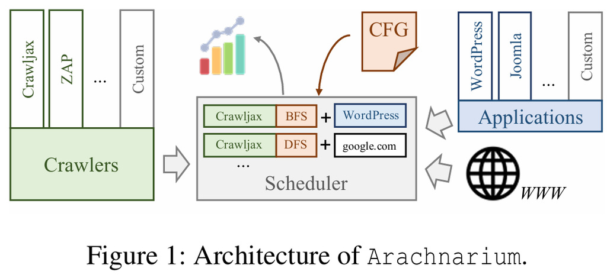

## Why care about these metrics?

- Code Coverage
  - A higher code coverage measures unique behaviours created by the server (server-side code)
- JavaScript Source Coverage
  - A higher javascript source coverage leads to better XSS - (Cross Site Scripting) detections
- Link Coverage
  - Better link coverage enables a more complete view of websites which can help prevent IDOR (Insecure Direct Object Reference) attacks

# How are the measurements calculated?

- Code Coverage
  - Code coverage is obtained via tools like XDebug interface, a debugging and profiling tool for PHP apps
- JavaScript Source Coverage
  - Extracts all script tags and calculates a SHA-512 hash
- Link Coverage
  - Extracts anchor tags and compares with exact matches of the href attribute

# IDOR Attacks

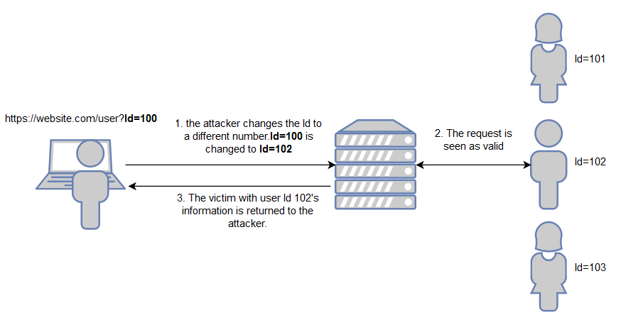